# **Shapley Speed - Julia vs the Rest**

2020-04-04

# **Purpose**

- The model-agnostic Shapley value approximation algorithm implemented in `ShapML` is computationally expensive. Because of this, the goal of this vignette is to (a) give a sense of the real-world clock time needed to explain datasets of various sizes and (b) compare these times to those from other popular open source packages implementing similar algorithms.

# **Setup**

- **Instances:** 1, 100, 1000
- **Features:** 10, 50, 200
- **Comparison packages:**
  - **fastshap** v0.0.5 in `R` with a `C++` back end
- **System**
  - Windows
  - Non-parallel computation
  - i7 8 GB laptop

# **Results**

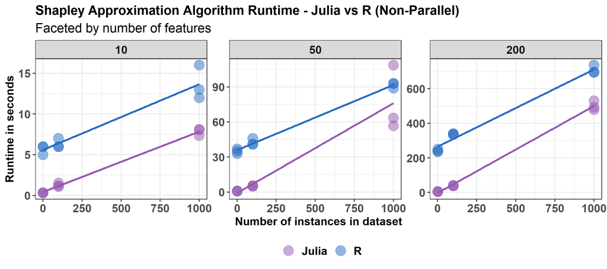

# **Simulations**

## **Load Packages**

### **`R`**

```r
library(dplyr)
library(fastshap)
library(ggplot2)
library(JuliaCall)
library(lubridate)
library(ranger)
library(tidyr)
```

```r
JuliaCall::julia_setup()

Sys.setenv(PATH = paste("C:/Users/nickr/AppData/Local/Julia-1.3.1/bin", Sys.getenv("PATH"), sep = ";"))
```

### **`Julia`**

```julia
using DataFrames
using Random
using RCall
using ShapML
```

## **Simulation Design in `R`**

```r
n_instances <- c(1, 100, 1000)
n_features <- c(10, 50, 200)

conditions <- expand.grid("n_features" = n_features, "n_instances" = n_instances)
conditions$condition <- 1:nrow(conditions)

n_conditions <- nrow(conditions)
n_models <- length(n_features)
n_simulations <- 3
n_monte_carlo <- 20
seed <- 1

conditions
```

| n_features | n_instances | condition |
| --- | --- | --- |
| 10 | 1 | 1 |
| 50 | 1 | 2 |
| 200 | 1 | 3 |
| 10 | 100 | 4 |
| 50 | 100 | 5 |
| 200 | 100 | 6 |
| 10 | 1000 | 7 |
| 50 | 1000 | 8 |
| 200 | 1000 | 9 |

## **Train ML Models in `R`**

- Create a series of synthetic datasets, one for each set of features–10, 50, 200. We’ll down-sample each dataset to create new datasets with fewer instances for the various conditions in the simulation.
- Train one Random Forest model for each set of features–10, 50, 200–with 1,000 instances.

```r
data_train <- vector("list", n_models)
models <- vector("list", n_models)

for(i in 1:n_models) {
  data_train[[i]] <- fastshap::gen_friedman(max(n_instances), n_features[i], seed = seed)
  models[[i]] <- ranger::ranger(y ~ ., data = data_train[[i]], seed = seed)
}

names(data_train) <- n_features
names(models) <- n_features
```

## **Duplicate Datasets & Models in `R`**

- Duplicate the 3 model datasets and models across 9 simulation conditions with the appropriate number of instances and features.

```r
data_explain <- vector("list", n_conditions)
models_condition <- vector("list", n_conditions)

for(i in 1:n_conditions) {

  data_condition <- data_train[[which(names(data_train) == as.character(conditions$n_features[i]))]]

  # 1 dataset of features to be explained for each condition.
  data_explain[[i]] <- data_condition[1:conditions$n_instances[i], !names(data_condition) %in% "y"]

  # 1 model for each condition.
  models_condition[[i]] <- models[[which(names(models) == as.character(conditions$n_features[i]))]]
}
```

## **Predict Wrapper Functions in `R`**

- The `predict()` functions will be written in `R` and then converted to `Julia` to work with the trained Random Forest model–which is not explicitly converted.

```r
predict_fun_r <- function(object, newdata) {
  predict(object, data = newdata)$predictions
}

predict_fun_julia <- function(model, data) {
  data_pred = data.frame("y_pred" = predict(model, data)$predictions)  # Must return a DataFrame.
  return(data_pred)
}
```

## **Shapley Value Calculations**

### **`R`**

- Explain model predictions with Shapley values using `fastshap`.

```r
data_shap_r <- vector("list", n_conditions)
data_shap_r <- lapply(data_shap_r, function(pass){vector("list", n_simulations)})
runtime_r <- vector("list", n_conditions)
runtime_r <- lapply(data_shap_r, function(pass){vector("list", n_simulations)})

for (i in 1:n_conditions) {
  for (j in 1:n_simulations) {

      set.seed(seed)
      start_time <- Sys.time()

      data_shap_r[[i]][[j]] <- fastshap::explain(models_condition[[i]],
                                                 X = data_explain[[i]],
                                                 pred_wrapper = predict_fun_r,
                                                 nsim = n_monte_carlo
                                                 )

      stop_time <- Sys.time()

      runtime_r[[i]][[j]] <- data.frame("time" = as.numeric(difftime(stop_time, start_time, units = "secs")),
                                        "condition" = i,
                                        "simulation" = j)

      print(runtime_r[[i]][[j]])
  }
}

runtime_r <- dplyr::bind_rows(unlist(runtime_r, recursive = FALSE))
```

### **`Julia`**

- Load `R` objects into the `Julia` environment.

```julia
n_conditions = RCall.reval("n_conditions")
n_conditions = convert(Integer, n_conditions)

n_simulations = RCall.reval("n_simulations")
n_simulations = convert(Integer, n_simulations)

models_condition = RCall.reval("models_condition")

predict_fun_julia = RCall.reval("predict_fun_julia")
predict_fun_julia = convert(Function, predict_fun_julia)

data_explain = RCall.reval("data_explain")

n_monte_carlo = RCall.reval("n_monte_carlo")
n_monte_carlo = convert(Integer, n_monte_carlo)

seed = RCall.reval("seed")
seed = convert(Integer, seed)
```

- Explain model predictions with Shapley values using `ShapML`.

```r
data_shap_julia = [Array{DataFrame}(undef, n_simulations) for i in 1:n_conditions]
runtime_julia = [Array{Any}(undef, n_simulations) for i in 1:n_conditions]

for i in 1:n_conditions
  for j in 1:n_simulations

      data_explain_temp = convert(DataFrame, data_explain[i])

      start_time = time()

      data_shap_julia[i][j] = ShapML.shap(explain = data_explain_temp,
                                          reference = data_explain_temp,
                                          model = models_condition[i],
                                          predict_function = predict_fun_julia,
                                          sample_size = n_monte_carlo,
                                          seed = seed
                                          )

      stop_time = time()

      runtime_julia[i][j] = DataFrame(time = stop_time - start_time, condition = i, simulation = j)
  end
end

runtime_julia = vcat(vcat(runtime_julia...)...)
```

## **Simulation Results**

```r
runtime_r$language <- "R"
runtime_julia$language <- "Julia"

data_runtime <- dplyr::bind_rows(runtime_r, runtime_julia)

data_runtime <- dplyr::left_join(data_runtime, conditions, by = "condition")
```

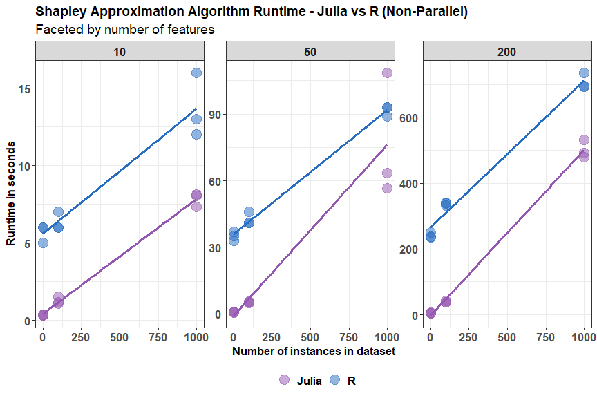

```r
plot_theme <- theme(
  strip.text = element_text(size = 12, face = "bold"),
  plot.title = element_text(size = 14, face = "bold"),
  plot.subtitle = element_text(size = 14),
  axis.title = element_text(size = 12, face = "bold"),
  axis.text.x = element_text(size = 12, face = "bold"),
  axis.text.y = element_text(size = 12, face = "bold"),
  legend.text = element_text(size = 12, face = "bold"),
  legend.position = "bottom"
)

p <- ggplot(data_runtime, aes(n_instances, time, color = language))
p <- p + geom_point(size = 5, alpha = .5)
p <- p + stat_smooth(method = "lm", se = FALSE, show.legend = FALSE, size = 1.1, alpha = .5)
p <- p + scale_color_manual(values = c("R" = "#276DC2", "Julia" = "#9558B2"))
p <- p + facet_wrap(~ n_features, scales = "free")
p <- p + theme_bw() + plot_theme
p <- p + xlab("Number of instances in dataset") + ylab("Runtime in seconds") + labs(color = NULL) +
  ggtitle("Shapley Approximation Algorithm Runtime - Julia vs R (Non-Parallel)",
          subtitle = "Faceted by number of features")
p_1 <- p
p_1
```

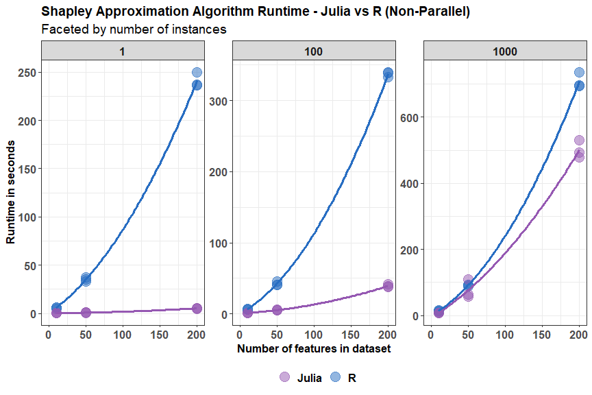

```r
p <- ggplot(data_runtime, aes(n_features, time, color = language))
p <- p + geom_point(size = 5, alpha = .5)
p <- p + stat_smooth(method = "lm", formula = y ~ poly(x, 2),
                     se = FALSE, show.legend = FALSE, size = 1.1, alpha = .5)
p <- p + scale_color_manual(values = c("R" = "#276DC2", "Julia" = "#9558B2"))
p <- p + scale_x_continuous(limits = c(0, 200))
p <- p + facet_wrap(~ n_instances, scales = "free")
p <- p + theme_bw() + plot_theme
p <- p + xlab("Number of features in dataset") + ylab("Runtime in seconds") + labs(color = NULL) +
  ggtitle("Shapley Approximation Algorithm Runtime - Julia vs R (Non-Parallel)",
          subtitle = "Faceted by number of instances")
p_2 <- p
p_2
```